# Housing_1 (2)

# 13-Show by graph the area which is the most selling one according to price

**Using a scatter plot to visualize the graphical representation of area and price**

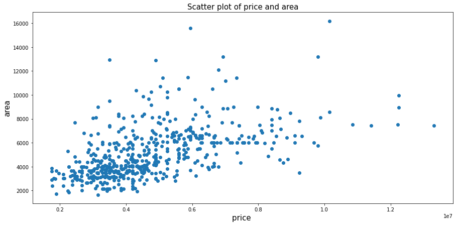

```python
plt.figure(figsize=(15, 7))
plt.scatter(df_house_price.price, df_house_price.area)
plt.xlabel("price ", fontsize=15)
plt.ylabel("area", fontsize=15)
plt.title("Scatter plot of price and area",fontsize=15)
plt.show()
```

# How air conditioned and non air conditioned houses can affected the house price

```python
pd.crosstab([df_house_price["airconditioning"]], df_house_price["price"],
            margins = True).style.background_gradient(cmap = "summer_r")
```

| price airconditioning | 1750000 | 1767150 | 1820000 | 1855000 | 1890000 | 1960000 | 2100000 | 2135000 | 2233000 | 2240000 | 2275000 | 2310000 | 2345000 | 2380000 | 2408000 | 2450000 | 2485000 | 2520000 | 2590000 | 2604000 | 2653000 | 2660000 | 2695000 | 2730000 | 2800000 | 2835000 | 2852500 | 2870000 | 2940000 | … |
| --- | --- | --- | --- | --- | --- | --- | --- | --- | --- | --- | --- | --- | --- | --- | --- | --- | --- | --- | --- | --- | --- | --- | --- | --- | --- | --- | --- | --- | --- | --- |
| 0 | 3 | 1 | 1 | 1 | 2 | 1 | 3 | 1 | 0 | 1 | 3 | 1 | 1 | 3 | 1 | 6 | 2 | 3 | 3 | 1 | 0 | 7 | 1 | 2 | 2 | 3 | 1 | 4 | 8 | … |
| 1 | 0 | 0 | 0 | 0 | 0 | 0 | 0 | 0 | 1 | 0 | 0 | 0 | 0 | 0 | 0 | 0 | 0 | 0 | 0 | 0 | 2 | 0 | 0 | 0 | 0 | 0 | 0 | 0 | 0 | … |
| All | 3 | 1 | 1 | 1 | 2 | 1 | 3 | 1 | 1 | 1 | 3 | 1 | 1 | 3 | 1 | 6 | 2 | 3 | 3 | 1 | 2 | 7 | 1 | 2 | 2 | 3 | 1 | 4 | 8 | … |

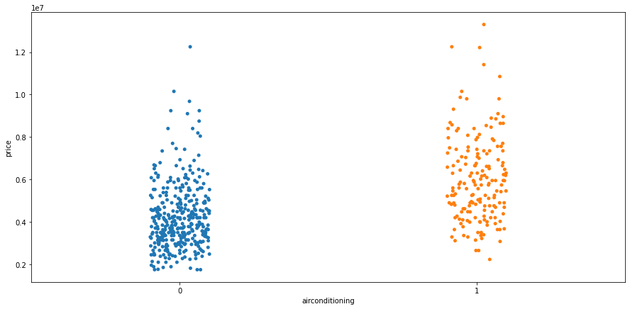

```python
f, ax = plt.subplots(figsize=(15, 7))
sns.stripplot(data = df_house_price, x='airconditioning', y='price', jitter=.1)
sns.set_context("paper", font_scale=1.1)
plt.show()
```

# Visualize the graph of basement

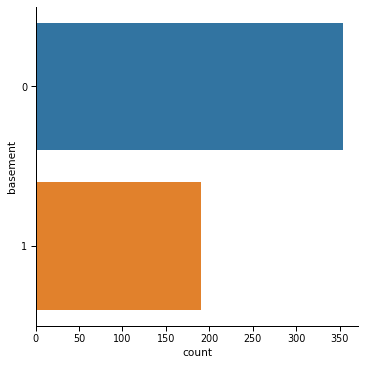

```python
fig=plt.figure(figsize=(12,4))
sns.catplot(y = 'basement', data =df_house_price , kind = "count", height = 5)
```

# How many house have hot water heating system and how many dont have

```python
df_house_price['hotwaterheating'].value_counts().to_frame()
```

|  | hotwaterheating |
| --- | --- |
| 0 | 520 |
| 1 | 25 |

```python
pd.crosstab([df_house_price["hotwaterheating"]], df_house_price["output"],
            margins = True).style.background_gradient(cmap = "summer_r")
```

| output hotwaterheating | 0 | 1 | 2 | All |
| --- | --- | --- | --- | --- |
| 0 | 134 | 213 | 173 | 520 |
| 1 | 6 | 14 | 5 | 25 |
| All | 140 | 227 | 178 | 545 |

# Visualize the graph of hot water system demand

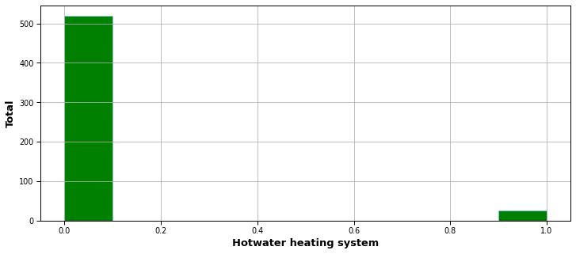

```python
plt.rcParams['figure.figsize']=(12,5)
df_house_price.hotwaterheating.hist(color = "g", ec="skyblue")
plt.xlabel('Hotwater heating system',fontweight='bold',fontsize=13)
plt.ylabel('Total',fontweight='bold',fontsize=13)
plt.show()
```

# Inspecting Data: Correlation of feature columns

```python
Corelation = df_house_price.corr()
Corelation
```

|  | price | area | bedrooms | bathrooms | stories | mainroad | guestroom | basement | hotwaterheating | airconditioning | parking | prefarea | output |
| --- | --- | --- | --- | --- | --- | --- | --- | --- | --- | --- | --- | --- | --- |
| price | 1.000000 | 0.535997 | 0.366494 | 0.517545 | 0.420712 | 0.296898 | 0.255517 | 0.187057 | 0.093073 | 0.452954 | 0.384394 | 0.329777 | -0.304721 |
| area | 0.535997 | 1.000000 | 0.151858 | 0.193820 | 0.083996 | 0.288874 | 0.140297 | 0.047417 | -0.009229 | 0.222393 | 0.352980 | 0.234779 | -0.171445 |
| bedrooms | 0.366494 | 0.151858 | 1.000000 | 0.373930 | 0.408564 | -0.012033 | 0.080549 | 0.097312 | 0.046049 | 0.160603 | 0.139270 | 0.079023 | -0.123244 |
| bathrooms | 0.517545 | 0.193820 | 0.373930 | 1.000000 | 0.326165 | 0.042398 | 0.126469 | 0.102106 | 0.067159 | 0.186915 | 0.177496 | 0.063472 | -0.143559 |
| stories | 0.420712 | 0.083996 | 0.408564 | 0.326165 | 1.000000 | 0.121706 | 0.043538 | -0.172394 | 0.018847 | 0.293602 | 0.045547 | 0.044425 | -0.104672 |
| mainroad | 0.296898 | 0.288874 | -0.012033 | 0.042398 | 0.121706 | 1.000000 | 0.092337 | 0.044002 | -0.011781 | 0.105423 | 0.204433 | 0.199876 | -0.156726 |
| guestroom | 0.255517 | 0.140297 | 0.080549 | 0.126469 | 0.043538 | 0.092337 | 1.000000 | 0.372066 | -0.010308 | 0.138179 | 0.037466 | 0.160897 | -0.118328 |
| basement | 0.187057 | 0.047417 | 0.097312 | 0.102106 | -0.172394 | 0.044002 | 0.372066 | 1.000000 | 0.004385 | 0.047341 | 0.051497 | 0.228083 | -0.112831 |
| hotwaterheating | 0.093073 | -0.009229 | 0.046049 | 0.067159 | 0.018847 | -0.011781 | -0.010308 | 0.004385 | 1.000000 | -0.130023 | 0.067864 | -0.059411 | -0.031628 |
| airconditioning | 0.452954 | 0.222393 | 0.160603 | 0.186915 | 0.293602 | 0.105423 | 0.138179 | 0.047341 | -0.130023 | 1.000000 | 0.159173 | 0.117382 | -0.150477 |
| parking | 0.384394 | 0.352980 | 0.139270 | 0.177496 | 0.045547 | 0.204433 | 0.037466 | 0.051497 | 0.067864 | 0.159173 | 1.000000 | 0.091627 | -0.177539 |
| prefarea | 0.329777 | 0.234779 | 0.079023 | 0.063472 | 0.044425 | 0.199876 | 0.160897 | 0.228083 | -0.059411 | 0.117382 | 0.091627 | 1.000000 | -0.107686 |
| output | -0.304721 | -0.171445 | -0.123244 | -0.143559 | -0.104672 | -0.156726 | -0.118328 | -0.112831 | -0.031628 | -0.150477 | -0.177539 | -0.107686 | 1.000000 |

# correlation from heatmap

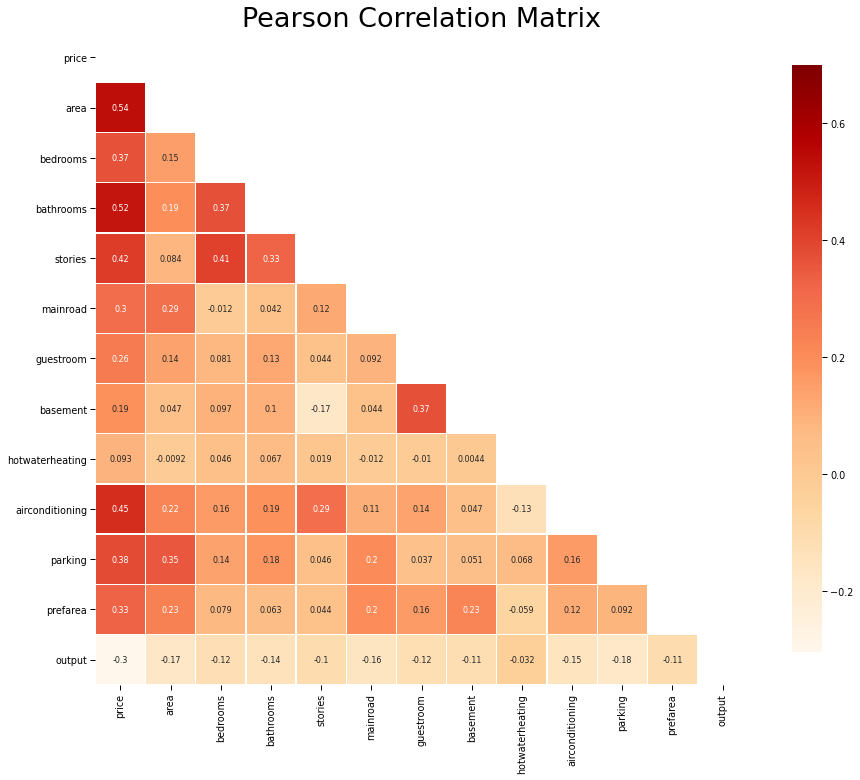

```python
features = ['price', 'area', 'bedrooms', 'bathrooms', 'stories', 'mainroad',  'guestroom', 'basement', 'hotwaterheating', 'airconditioning',
             'parking', 'prefarea', 'output']
mask = np.zeros_like(df_house_price[features].corr(), dtype=np.bool)
mask[np.triu_indices_from(mask)] = True
f, ax = plt.subplots(figsize=(16, 12))
plt.title('Pearson Correlation Matrix',fontsize=27)
sns.heatmap(df_house_price[features].corr(),linewidths=0.25,vmax=0.7,square=True,cmap="OrRd",
linecolor='w',annot=True,annot_kws={"size":8},mask=mask,cbar_kws={"shrink": .9});
```

## Predicting Price

```python
## Lets Split Dataset
```

```python
#splitting
y=df_house_price.price
x=df_house_price.drop('price',axis=1)
```

## Train and Test Split Data

```python
X_train, X_test, y_train, y_test = train_test_split(x, y, test_size = 0.2, random_state = 42)
print ("X_train: ", len(X_train))
print("X_test: ", len(X_test))
print("y_train: ", len(y_train))
print("y_test: ", len(y_test))
```

```
X_train:  436
X_test:  109
y_train:  436
y_test:  109
```

### Regression Evaluation Metrics¶

### Here are three common evaluation metrics for regression problems:

- Mean Absolute Error (MAE) is the mean of the absolute value of the errors:
- Mean Squared Error (MSE) is the mean of the squared errors:
- Root Mean Squared Error (RMSE) is the square root of the mean of the squared errors:

### Comparing these metrics:

1. MAE is the easiest to understand, because it's the average error.
2. MSE is more popular than MAE, because MSE "punishes" larger errors, which tends to be useful in the real world.
3. RMSE is even more popular than MSE, because RMSE is interpretable in the "y" units

```python
from sklearn.metrics import r2_score,mean_squared_error,mean_squared_log_error,make_scorer
from sklearn.linear_model import LinearRegression
from sklearn.ensemble import RandomForestRegressor
from xgboost import XGBRegressor
from lightgbm import LGBMRegressor
from sklearn.pipeline import make_pipeline
from sklearn.model_selection import KFold
from sklearn.metrics import mean_squared_error
from sklearn.metrics import mean_absolute_error
```

```python
from sklearn import metrics
from sklearn.model_selection import cross_val_score

def cross_val(model):
    pred = cross_val_score(model, x, y, cv=10)
    return pred.mean()

def print_evaluate(true, predicted):
    mae = metrics.mean_absolute_error(true, predicted)
    mse = metrics.mean_squared_error(true, predicted)
    rmse = np.sqrt(metrics.mean_squared_error(true, predicted))
    r2_square = metrics.r2_score(true, predicted)
    print('MAE:', mae)
    print('MSE:', mse)
    print('RMSE:', rmse)
    print('R2 Square', r2_square)

def evaluate(true, predicted):
    mae = metrics.mean_absolute_error(true, predicted)
    mse = metrics.mean_squared_error(true, predicted)
    rmse = np.sqrt(metrics.mean_squared_error(true, predicted))
    r2_square = metrics.r2_score(true, predicted)
    return mae, mse, rmse, r2_square
```

### 1) Linear Regression

```python
ModelAccuracy=[]
RegModel=[]
```

```python
lrregressor = LinearRegression()
lrregressor.fit(X_train,y_train)
```

```
LinearRegression(copy_X=True, fit_intercept=True, n_jobs=None, normalize=False)
```

```python
accuracy = lrregressor.score(X_test,y_test)
print(accuracy*100,'%')
ModelAccuracy.append(accuracy*100)
RegModel.append("Linear Regression")
```

```
64.94754192267804 %
```

### First 10 Prediction of Model

```python
lr_pred = lrregressor.predict(X_test)
lr_pred[:10]
```

```
array([5203691.70963178, 7257004.02115476, 3062828.59668171,
       4559591.65374424, 3332932.30559782, 3563080.67918997,
       5645466.31219972, 6413979.66873635, 2755831.54819   ,
       2668938.66075228])
```

### Linear Regression Evaluation Metrics

```python
# Model Evaluation
print('R^2:',metrics.r2_score(y_test, lr_pred))
print('MAE:',metrics.mean_absolute_error(y_test, lr_pred))
print('MSE:',metrics.mean_squared_error(y_test, lr_pred))
print('RMSE:',np.sqrt(metrics.mean_squared_error(y_test, lr_pred)))
```

```
R^2: 0.6494754192267804
MAE: 979679.6912959901
MSE: 1771751116594.0344
RMSE: 1331071.4167895103
```

## Prices vs LR Predicted prices

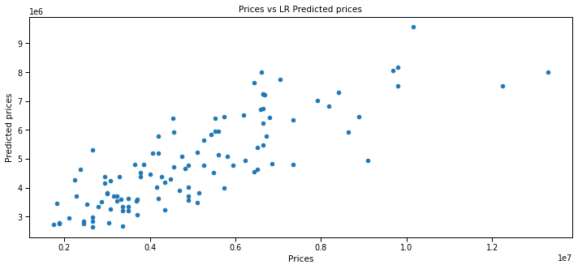

```python
plt.scatter(y_test,lr_pred)
plt.xlabel("Prices")
plt.ylabel("Predicted prices")
plt.title("Prices vs LR Predicted prices")
plt.show()
```

### 2) LASSO Regression

A linear model that estimates sparse coefficients. Mathematically, it consists of a linear model trained with ℓ1 prior as regularizer.

```python
from sklearn.linear_model import Lasso
lassomodel = Lasso()
lassomodel.fit(X_train, y_train)
```

```
Lasso(alpha=1.0, copy_X=True, fit_intercept=True, max_iter=1000,
      normalize=False, positive=False, precompute=False, random_state=None,
      selection='cyclic', tol=0.0001, warm_start=False)
```

```python
accuracy = lassomodel.score(X_test,y_test)
ModelAccuracy.append(accuracy*100)
RegModel.append("Lasso Regression")
```

```python
print(accuracy*100,'%')
```

```
64.94747129728069 %
```

```python
lassopred = lassomodel.predict(X_test)
lassopred[:10]
```

```
array([5203700.45125713, 7256998.48190896, 3062832.09258887,
       4559591.4182286 , 3332935.19273046, 3563086.55844606,
       5645468.93977034, 6413970.556327  , 2755836.92689116,
       2668947.9765852 ])
```

## LASSO Regression Evaluation Metrics

```python
# Model Evaluation
print('R^2:',metrics.r2_score(y_test, lassopred))
print('MAE:',metrics.mean_absolute_error(y_test, lassopred))
print('MSE:',metrics.mean_squared_error(y_test, lassopred))
print('RMSE:',np.sqrt(metrics.mean_squared_error(y_test, lassopred)))
```

```
R^2: 0.6494747129728069
MAE: 979680.730778263
MSE: 1771754686404.3557
RMSE: 1331072.7577425495
```

## Prices vs Lasso Predicted prices

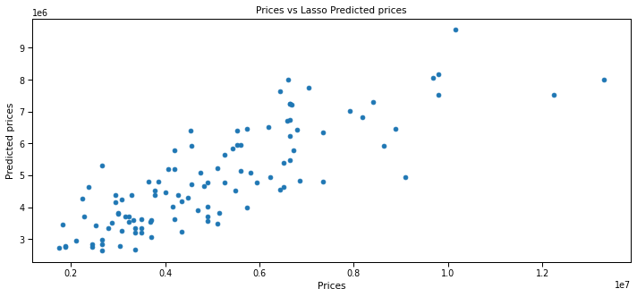

```python
plt.scatter(y_test,lassopred)
plt.xlabel("Prices")
plt.ylabel("Predicted prices")
plt.title("Prices vs Lasso Predicted prices")
plt.show()
```

## RandomForestRegressor

A random forest is a meta estimator that fits a number of classifying decision trees on various sub-samples of the dataset and uses averaging to improve the predictive accuracy and control over-fitting.

```python
rfrmodel=RandomForestRegressor()
rfrmodel.fit(X_train, y_train)
```

```
RandomForestRegressor(bootstrap=True, ccp_alpha=0.0, criterion='mse',
                      max_depth=None, max_features='auto', max_leaf_nodes=None,
                      max_samples=None, min_impurity_decrease=0.0,
                      min_impurity_split=None, min_samples_leaf=1,
                      min_samples_split=2, min_weight_fraction_leaf=0.0,
                      n_estimators=100, n_jobs=None, oob_score=False,
                      random_state=None, verbose=0, warm_start=False)
```

```python
accuracy = rfrmodel.score(X_test,y_test)
print(accuracy*100,'%')
ModelAccuracy.append(accuracy*100)
RegModel.append("RandomForest Regression")
```

```
61.66117291927235 %
```

```python
rf_pred = lrregressor.predict(X_test)
rf_pred[:10]
```

```
array([5203691.70963178, 7257004.02115476, 3062828.59668171,
       4559591.65374424, 3332932.30559782, 3563080.67918997,
       5645466.31219972, 6413979.66873635, 2755831.54819   ,
       2668938.66075228])
```

```python
# Model Evaluation
print('R^2:',metrics.r2_score(y_test, rf_pred))
print('MAE:',metrics.mean_absolute_error(y_test, rf_pred))
print('MSE:',metrics.mean_squared_error(y_test, rf_pred))
print('RMSE:',np.sqrt(metrics.mean_squared_error(y_test, rf_pred)))
```

[output not shown]

[figure not shown]

```python
plt.scatter(y_test,rf_pred)
plt.xlabel("Prices")
plt.ylabel("Predicted prices")
plt.title("Prices vs RF Predicted prices")
plt.show()
```

```python
from xgboost import XGBRegressor

#Create a XGBoost Regressor
reg = XGBRegressor()

# Train the model using the training sets
reg.fit(X_train, y_train)

# Model prediction on train data
XGB_pred = reg.predict(X_test)
```

```
[00:42:05] WARNING: /workspace/src/objective/regression_obj.cu:152: reg:linear is now deprecated in favor of reg:squarederror.
```

```python
accuracy = reg.score(X_test,y_test)
print(accuracy*100,'%')
ModelAccuracy.append(accuracy*100)
RegModel.append("XGBRegressor Regression")
```

```
67.09112368571269 %
```

## XGBRegressor Evaluation

```python
# Model Evaluation
print('R^2:',metrics.r2_score(y_test, XGB_pred))
print('MAE:',metrics.mean_absolute_error(y_test, XGB_pred))
print('MSE:',metrics.mean_squared_error(y_test, XGB_pred))
print('RMSE:',np.sqrt(metrics.mean_squared_error(y_test, XGB_pred)))
```

```
R^2: 0.6709112368571268
MAE: 946525.5642201835
MSE: 1663402270593.2925
RMSE: 1289729.5338920066
```

## Prices vs XGB Predicted prices

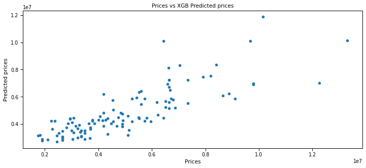

```python
plt.scatter(y_test,XGB_pred)
plt.xlabel("Prices")
plt.ylabel("Predicted prices")
plt.title("Prices vs XGB Predicted prices")
plt.show()
```

## Model Accuracys

```python
ModelAccuracy
```

```
[64.94754192267804, 64.94747129728069, 61.66117291927235, 67.09112368571269]
```

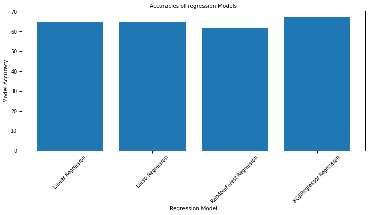

```python
Index = [1,2,3,4]
plt.bar(Index,ModelAccuracy)
plt.xticks(Index, RegModel,rotation=45)
plt.ylabel('Model Accuracy')
plt.xlabel('Regression Model')
plt.title('Accuracies of regression Models')
```